# do_RSA_v10_Searchlight

LC

2024-05-03

# Set paramters manually

```r
# ratings_type can be emotion, arousal, valence
ratings_type <- "arousal"

# must be one of the masks in rsa/masks
gm_file <- "test_mask"

# Define searchlight radius in mm
r_mm <- 4

# if set to TOP_RATERS, it will use only the subs below
subs_selection = "ALLSUBS"
top_raters_subs <- c("02","03","12","11","22","09","29","28","26","32","23","15","20","19")
```

# Load libraries and define parameters

This script is a modification to use a searchlight, instead of a parcellation/atlas.

NB: this Rmd can be used for all types of ratings: emotion, arousal, valence

Abbreviations: - sub : subjects(s) - rat : rating(s)

```r
library(tidyverse)
library(future)
library(furrr)
library(tictoc)
library(RNifti)
library(proxy) # distances
library(profvis)
library(DT)
library(formattable)

source("funs_V10_Searchlight.R")

bd="/data00/leonardo/RSA/analyses"

# the following is our contrast of interest and it's always the same
copes_type <- "one_ev_per_movie"

cat("Using", ratings_type, "rating\n\n")
```

```
## Using arousal rating
```

```r
cat("Calculating RSA for every voxel in the", gm_file, "mask\n")
```

```
## Calculating RSA for every voxel in the test_mask mask
```

```r
cat("using a searchlight of", r_mm, "mm\n\n")
```

```
## using a searchlight of 4 mm
```

```r
# # Point to which gray matter mask to use for searchlight
# # GM_clean
# # insula_HO_GM
# gm_file <- "test_mask"
gm_path <- paste0(bd,"/rsa/masks/", gm_file, ".nii.gz")




# Choose the distance metric to use for fmri RDM
# The metric for ratings RDM *should be* euclidean, since arousal and valence
# ratings have only one value
# Supported methods: 'pearson', 'spearman', 'euclidean', 'cosine' or 'mahalanobis'
dist_method_rating <- "euclidean"
dist_method_fmri = "euclidean"
dist_method_rsa = "pearson"

cat(paste0("Ratings RDM to be calculated with : ", dist_method_rating, "\n"))
```

```
## Ratings RDM to be calculated with : euclidean
```

```r
cat(paste0("fMRI RDM to be calculated with : ", dist_method_fmri, "\n"))
```

```
## fMRI RDM to be calculated with : euclidean
```

```r
# for RDM_type use:
# - tril for the lower triangular of the D matrix
# - svd for the first 3 pc from svd of the D matrix
# - in case of svd, set the number of components to return with ncomp_svd
RDM_type = "tril"  # svd or tril. Must be the same for both rating and fmri
ncomp_svd = 3

# Vector of zeropadded sub_ids
subs_file <- "/data00/leonardo/RSA/sub_list.txt"
subs <- sprintf("%02d",readLines(subs_file) %>% as.numeric)

# ---------- ONLY TOP RATERS BELOW ------------
if (subs_selection == "TOP_RATERS") {
  subs <- top_raters_subs
  cat("\nOnly the", length(subs), "top raters")
} else {
  cat("\nAll", length(subs), "subs")
}
```

```
##
## All 26 subs
```

# Aux functions

```r
# plot_heatmap(D %>% as.matrix)
plot_heatmap <- function(M) {
  heatmap(M, Rowv = NA, Colv = NA, symm=T, revC = T)
}
```

# Create a df_path_copes with the location of the 56 cope niis from the one_movie_per_ev model

Extract the pathname of all copes using the `list.files()` function. Also define a copes_numba vector with all the copes numbers.

NB: The cope numbers in the `cope` column are NOT zeropadded since this is how they come out from FSL Feat

```r
copes_location_csv <- paste0(bd,"/rsa/copes_location.csv")

df_path_copes <- if (file.exists(copes_location_csv) ) {
  df_path_copes <- read_csv(copes_location_csv)
} else {
  df_path_copes <- import_df_path_copes(bd, copes_type)
}

copes_numba <- df_path_copes$cope %>% unique

# df_path_copes
```

# Calculate RATINGS RDMs

We do this first since the RDM for the ratings will be the same for whatever atlas will be used. Also, it’s much faster than the RDM_fmri and can be done for all the sub_ids at once.

- **tril** : The final RDMs_rats has 40040 nrows : 26 sub_ids * 1540, where the latter derives from ((56^2)-56)/2 = 1540, i.e. tril from the D matrix of 56 movies
- **svd** : The final RDMs_rats has 4368 nrows : 26 sub_ids * 168, where the latter derives from 56*3, i.e. the first three components from svd of the D matrix

```r
bd_ratings = paste0(bd,"/RATINGS")
ratings_path <- paste0(bd_ratings,"/",ratings_type,"_ratings.csv")
rats <- read_csv(ratings_path)

# cols are subs
# rows are elements of the tril
RDMs_rats_wider <- subs %>% map_dfc(~ {
  do_RDM_ratings_one_sub(.x, dist_method_rating, rats, RDM_type =  RDM_type)
})

# pivot the df above so that there is only one col for subs
# and one for the values of the tril for each sub
RDMs_rats <- RDMs_rats_wider %>%
  pivot_longer(cols = everything(), names_to = "sub") %>%
  arrange(sub)

RDMs_rats
```

```
## # A tibble: 40,040 × 2
##    sub   value
##    <chr> <dbl>
##  1 02        3
##  2 02        1
##  3 02        5
##  4 02        0
##  5 02        3
##  6 02        0
##  7 02        5
##  8 02        7
##  9 02        7
## 10 02        1
## # ℹ 40,030 more rows
```

# Calculate fMRI RDMs

## Create SEARCHLIGHT regions

This code cell yields two outputs:

- `idx` : the index of each voxel in the mask, i.e. an integer from 1 to 91x109x91
- `idx_within_radius` : a list of list: each inner list contains the index of the voxels which are within the defined radius, i.e. within the searchlight having that voxel as a ‘center’.

Note that not all voxels have the same numba of other voxels within their searchlight. The histogram below shows the distribution of numba of voxels in the searchlight for each voxel in the mask.

```r
# 1. Read the gm mask and get voxel size, get idx of voxels in gm and their
#    xyz coordinates
gm <- readNifti(gm_path)
voxel_size <- pixdim(gm) %>% mean   # voxel size of gm
idx <- which(gm != 0)   # index of nonzero voxels
coords <- which(gm != 0, arr.ind = TRUE)   # get coordinates


# 2. Define a searchlight function returning the volume (92x109x92) idx of the
#    voxels within the searchlight
searchlight <- function(center_coord, r_mm, coords, idx, voxel_size) {

  # Calculate distance of the given voxel from every other voxel, considering voxel size
  distances <- sqrt(rowSums((t(t(coords) - center_coord) * voxel_size)^2))

  # # TEST ONLY: return the coords of the voxels in the searchlight
  # return(coords[distances <= r_mm, , drop = FALSE])

  # return the idx of the voxels in the searchlight
  return(idx[distances <= r_mm])
}


# # Testing the searchlight fn with one coordinate
# # See also the nb : earchlight_development.Rmd
# mycoord <- coords[1,]
# idx_within_radius <- searchlight(mycoord, r_mm=6, coords, idx, voxel_size)

# # Convert indices to coordinates (just to check)
# mycoord
# coords_within_radius <- coords[match(idx_within_radius, idx), , drop = FALSE]
# coords_within_radius


# 3. Get the idx of the vxls within radius for each voxel in gm (~ 20 sec)
plan(multisession, workers = 15)

tic()

idx_within_radius <- 1:length(idx) %>% future_map(
  ~ searchlight(coords[.x,], r_mm, coords, idx, voxel_size)
)

toc()
```

```
## 5.928 sec elapsed
```

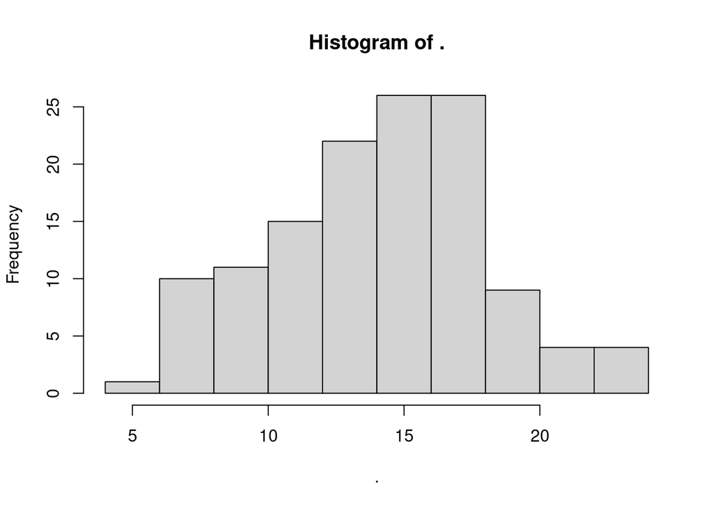

```r
plan(sequential)

#
idx_within_radius %>% map_dbl(length) %>% hist
```

## Fn to carry out the RMDs Searchlight calculation for one sub

```r
# In order to test for one sub, I need to load the corresponding df_copes.
# In the next cells the df_copes of each sub are dynamically loaded
# when subs %>% future_map_dfr
sub_id = "02"
df_copes <- load_sub_copes(sub_id, copes_numba, df_path_copes)


calculate_fmri_RDMs_Searchlight <- function(df_copes, idx, idx_within_radius) {

  one_rdm <- idx_within_radius %>% map_dfc(~ {
    idx_spot <- unlist(.x)
    df_copes_region <- df_copes[idx_spot, ]

    # center (i.e. demean) variables
    # (treat also the case of single voxels)
    if(nrow(df_copes_region) > 1) {
      df_copes_region_demean <- df_copes_region %>%
        mutate(across(everything(), ~ .x - mean(.x)))
    } else {
      df_copes_region_demean <- df_copes_region
    }

    # calculate distance / similarity
    D_fmri <- DDOS( t(df_copes_region_demean), method = dist_method_fmri )
    D_fmri[is.na(D_fmri)] <- 0

    # flat onto a vector
    D_feature_vector <- D_fmri[!is.na(D_fmri)]
  })

  colnames(one_rdm) = idx

  return(one_rdm)
}

# Again the following is just for testing on one sub
# ~ 90 seconds, no need to use furrr
N <- 10 #length(idx)
one_RDM_fmri <- calculate_fmri_RDMs_Searchlight(df_copes, idx[1:N], idx_within_radius[1:N])

one_RDM_fmri
```

```
## # A tibble: 1,540 × 10
##    `304150` `304151` `304152` `304153` `304154` `314067` `314068` `314069`
##       <dbl>    <dbl>    <dbl>    <dbl>    <dbl>    <dbl>    <dbl>    <dbl>
##  1     188.     269.     478.     509.     372.    419.      251.     254.
##  2     104.     143.     196.     193.     144.    267.      178.     188.
##  3     218.     271.     305.     239.     136.     63.7     205.     314.
##  4     145.     234.     466.     540.     414.    210.      191.     190.
##  5    1261.    1223.    1089.     600.     210.    614.     1115.    1589.
##  6     432.     399.     330.     224.     123.    459.      414.     516.
##  7     652.     626.     536.     382.     220.    133.      486.     705.
##  8     182.     289.     359.     301.     163.    128.      234.     301.
##  9     518.     387.     379.     398.     338.    830.      879.     886.
## 10     132.     119.     184.     203.     124.    244.      125.     209.
## # ℹ 1,530 more rows
## # ℹ 2 more variables: `314070` <dbl>, `314071` <dbl>
```

## Furrr the RDMs Searchlight calculation across subs

```r
# for testing on a subset of idx
N = length(idx)

# 5 workers give the best performance
plan(multisession, workers = 10)

tic()
RDMs_fmri <- subs %>% future_map_dfr(~{

  paste0("Calculating RDMs Searchlight for sub ",.x,"\n") %>% cat

  df_copes <- load_sub_copes(.x, copes_numba, df_path_copes)

  one_RDM_fmri <- calculate_fmri_RDMs_Searchlight(
    df_copes,
    idx[1:N],
    idx_within_radius[1:N]
  )

  one_RDM_fmri %>% mutate(sub = .x) %>% relocate(sub)

})
```

```
## Calculating RDMs Searchlight for sub 02
## Calculating RDMs Searchlight for sub 03
## Calculating RDMs Searchlight for sub 05
## Calculating RDMs Searchlight for sub 07
## Calculating RDMs Searchlight for sub 09
## Calculating RDMs Searchlight for sub 10
## Calculating RDMs Searchlight for sub 11
## Calculating RDMs Searchlight for sub 12
## Calculating RDMs Searchlight for sub 14
## Calculating RDMs Searchlight for sub 15
## Calculating RDMs Searchlight for sub 16
## Calculating RDMs Searchlight for sub 18
## Calculating RDMs Searchlight for sub 19
## Calculating RDMs Searchlight for sub 20
## Calculating RDMs Searchlight for sub 21
## Calculating RDMs Searchlight for sub 22
## Calculating RDMs Searchlight for sub 23
## Calculating RDMs Searchlight for sub 24
## Calculating RDMs Searchlight for sub 26
## Calculating RDMs Searchlight for sub 27
## Calculating RDMs Searchlight for sub 28
## Calculating RDMs Searchlight for sub 29
## Calculating RDMs Searchlight for sub 30
## Calculating RDMs Searchlight for sub 31
## Calculating RDMs Searchlight for sub 32
## Calculating RDMs Searchlight for sub 34
```

```r
toc()
```

```
## 22.782 sec elapsed
```

```r
plan(sequential)
```

# RSA Searchlight

## Calculate RSA and mean RSA across subs inside a tibble

```r
rdms_fmri_nested <- RDMs_fmri %>%
  pivot_longer(cols = !starts_with("sub"), names_to = "region") %>%
  group_by(sub,region) %>%
  nest() %>%
  rename(fmri = data)


rdms_rats_nested <- RDMs_rats %>%
  group_by(sub) %>%
  nest %>%
  rename(rat = data)


# we put a copy of the rating RDM for each atlas region's RDM
joint_fmri_rat_nested <- right_join(rdms_fmri_nested,rdms_rats_nested, by = "sub")
# # the following is just to check that the join went as expected
# ff %>% mutate(sum_rat = rat %>% map_dbl(sum)  )

joint_fmri_rat_nested
```

```
## # A tibble: 3,328 × 4
## # Groups:   sub, region [3,328]
##    sub   region fmri                 rat
##    <chr> <chr>  <list>               <list>
##  1 02    304150 <tibble [1,540 × 1]> <tibble [1,540 × 1]>
##  2 02    304151 <tibble [1,540 × 1]> <tibble [1,540 × 1]>
##  3 02    304152 <tibble [1,540 × 1]> <tibble [1,540 × 1]>
##  4 02    304153 <tibble [1,540 × 1]> <tibble [1,540 × 1]>
##  5 02    304154 <tibble [1,540 × 1]> <tibble [1,540 × 1]>
##  6 02    314067 <tibble [1,540 × 1]> <tibble [1,540 × 1]>
##  7 02    314068 <tibble [1,540 × 1]> <tibble [1,540 × 1]>
##  8 02    314069 <tibble [1,540 × 1]> <tibble [1,540 × 1]>
##  9 02    314070 <tibble [1,540 × 1]> <tibble [1,540 × 1]>
## 10 02    314071 <tibble [1,540 × 1]> <tibble [1,540 × 1]>
## # ℹ 3,318 more rows
```

```r
# Calculate all RSA for each sub and each region/voxel
# and also round similarity and fix region data type
RSA <- joint_fmri_rat_nested %>%
  mutate(
    similarity = list(fmri,rat) %>% pmap_dbl(~ cor(.x,.y, method = dist_method_rsa))
  ) %>%
  ungroup %>%
  mutate(
    region = as.integer(region),
    similarity = round(similarity, 3)
  )

# Estimate avg_RSA
avg_RSA <- RSA %>%
  select(region, similarity) %>%
  group_by(region) %>%
  reframe(
    mean_similarity = round(mean(similarity),2),
    sd_similarity = round(sd(similarity),2)
  ) %>%
  arrange(desc(mean_similarity))

avg_RSA %>% datatable()
```

|  | region | mean_similarity | sd_similarity |
| --- | --- | --- | --- |
| 1 | 334002 | 0.04 | 0.06 |
| 2 | 334092 | 0.04 | 0.06 |
| 3 | 334093 | 0.04 | 0.06 |
| 4 | 343823 | 0.03 | 0.05 |
| 5 | 343920 | 0.03 | 0.06 |
| 6 | 344012 | 0.03 | 0.05 |
| 7 | 344102 | 0.03 | 0.05 |
| 8 | 344103 | 0.03 | 0.06 |
| 9 | 353742 | 0.03 | 0.05 |
| 10 | 354021 | 0.03 | 0.05 |

[output cut: 118 more lines]

## Write the RSA results to niis

Two types of results are written in nii images, for each voxel in the mask: - the RSA for each sub - the average RSA across subs

### Define `results_flavor` and create `results_dir`

The following chunk is all to create an informative name for the results dir for this particular mask, rating type and distance methods, as well as to create the directory if it does not exist yet

```r
# NB: [results_flavour].nii.gz will also be the name of the avg RSA across subs
results_flavour <- generate_results_flavour(
  gm_file, dist_method_rating, dist_method_fmri, dist_method_rsa, subs
)

rsa_results_path <- paste0(bd, "/rsa/rsa_results")
results_dir <- paste0(rsa_results_path, "/", results_flavour)

# Create the results if it does not exist
if (!dir.exists(results_dir)) {
  # Create the directory if it does not exist
  dir.create(results_dir, recursive = TRUE)
  print(paste0("Created ", results_dir))
} else {
  print(paste0(results_dir, " already exists"))
}
```

```
## [1] "Created /data00/leonardo/RSA/analyses/rsa/rsa_results/N26_test_mask_EER"
```

### Write the RSA nii for each sub - these will be used by `randomise`

```r
# Using the function write_RSA_results_to_nii. Documentation in the funs_[Vx]_Searchlight.R

RSA %>%
  select(sub, region, similarity) %>%
  group_split(sub) %>%
  walk(~ write_RSA_results_to_nii(.x, ratings_type, results_dir, gm))
```

```
## /data00/leonardo/RSA/analyses/rsa/rsa_results/N26_test_mask_EER/sub_02_RSA_arousal.nii.gz
## /data00/leonardo/RSA/analyses/rsa/rsa_results/N26_test_mask_EER/sub_03_RSA_arousal.nii.gz
## /data00/leonardo/RSA/analyses/rsa/rsa_results/N26_test_mask_EER/sub_05_RSA_arousal.nii.gz
## /data00/leonardo/RSA/analyses/rsa/rsa_results/N26_test_mask_EER/sub_07_RSA_arousal.nii.gz
## /data00/leonardo/RSA/analyses/rsa/rsa_results/N26_test_mask_EER/sub_09_RSA_arousal.nii.gz
## /data00/leonardo/RSA/analyses/rsa/rsa_results/N26_test_mask_EER/sub_10_RSA_arousal.nii.gz
## /data00/leonardo/RSA/analyses/rsa/rsa_results/N26_test_mask_EER/sub_11_RSA_arousal.nii.gz
## /data00/leonardo/RSA/analyses/rsa/rsa_results/N26_test_mask_EER/sub_12_RSA_arousal.nii.gz
## /data00/leonardo/RSA/analyses/rsa/rsa_results/N26_test_mask_EER/sub_14_RSA_arousal.nii.gz
## /data00/leonardo/RSA/analyses/rsa/rsa_results/N26_test_mask_EER/sub_15_RSA_arousal.nii.gz
## /data00/leonardo/RSA/analyses/rsa/rsa_results/N26_test_mask_EER/sub_16_RSA_arousal.nii.gz
## /data00/leonardo/RSA/analyses/rsa/rsa_results/N26_test_mask_EER/sub_18_RSA_arousal.nii.gz
## /data00/leonardo/RSA/analyses/rsa/rsa_results/N26_test_mask_EER/sub_19_RSA_arousal.nii.gz
## /data00/leonardo/RSA/analyses/rsa/rsa_results/N26_test_mask_EER/sub_20_RSA_arousal.nii.gz
## /data00/leonardo/RSA/analyses/rsa/rsa_results/N26_test_mask_EER/sub_21_RSA_arousal.nii.gz
## /data00/leonardo/RSA/analyses/rsa/rsa_results/N26_test_mask_EER/sub_22_RSA_arousal.nii.gz
## /data00/leonardo/RSA/analyses/rsa/rsa_results/N26_test_mask_EER/sub_23_RSA_arousal.nii.gz
## /data00/leonardo/RSA/analyses/rsa/rsa_results/N26_test_mask_EER/sub_24_RSA_arousal.nii.gz
## /data00/leonardo/RSA/analyses/rsa/rsa_results/N26_test_mask_EER/sub_26_RSA_arousal.nii.gz
## /data00/leonardo/RSA/analyses/rsa/rsa_results/N26_test_mask_EER/sub_27_RSA_arousal.nii.gz
## /data00/leonardo/RSA/analyses/rsa/rsa_results/N26_test_mask_EER/sub_28_RSA_arousal.nii.gz
## /data00/leonardo/RSA/analyses/rsa/rsa_results/N26_test_mask_EER/sub_29_RSA_arousal.nii.gz
## /data00/leonardo/RSA/analyses/rsa/rsa_results/N26_test_mask_EER/sub_30_RSA_arousal.nii.gz
## /data00/leonardo/RSA/analyses/rsa/rsa_results/N26_test_mask_EER/sub_31_RSA_arousal.nii.gz
## /data00/leonardo/RSA/analyses/rsa/rsa_results/N26_test_mask_EER/sub_32_RSA_arousal.nii.gz
## /data00/leonardo/RSA/analyses/rsa/rsa_results/N26_test_mask_EER/sub_34_RSA_arousal.nii.gz
```

### Write the avg_RSA nii - for viz

```r
write_avg_RSA_to_nii <- function(avg_RSA, results_flavour,
                                 ratings_type, rsa_results_path, gm) {

  results_nii <- gm

  idx_voxel <- avg_RSA$region
  results_nii[idx_voxel] = avg_RSA$mean_similarity

  nii2write_path <- paste0(rsa_results_path,"/", results_flavour, "_", ratings_type,".nii.gz")
  cat(paste0(nii2write_path,"\n"))

  writeNifti(results_nii, nii2write_path)
}


write_avg_RSA_to_nii(avg_RSA, results_flavour, ratings_type, rsa_results_path, gm)
```

```
## /data00/leonardo/RSA/analyses/rsa/rsa_results/N26_test_mask_EER_arousal.nii.gz
```